```python
%%javascript
IPython.OutputArea.prototype._should_scroll = function(lines) {
    return false;
}
```

```python
# to load images for this tutorial
from IPython.display import Image
import os
path = os.getcwd()
```

# Post Goals:

1. Discuss the statistical distributions.
2. Discuss Bernoulli Distributions.
3. Demonstrate how to visualize the Probability Mass Function and the Cumulative Distribution Function for Bernoulli Distributions.

# Post Overview.

1. Primer on Statistical Distributions
2. Bernoulli (Binomial) Distribution
3. Mathematical Intuition for Bernoulli Distribution
4. Common Binomial Distribution Statistics
5. Visualizing the Binomial Probability Density Function
6. Visualizing the Binomial Cumulative Density Function

# Primer on Statistical Distributions

**What are statistical distributions?**

- A statistical distribution is the distribution that describes the relative number of times each possible outcome will occur in a number of trials.
- Statistical distributions provide a parameterized mathematical function that can be used to calculate the probability of any instance or observation from a sample data.
- Statistical distributions are described by probability distributions functions, and two commonly probability functions is the **Probability density function (PDF)** and the **Cumulative distribution function (CDF)**.
- The **Probability density function (PDF)** gives the probability of a given value will occur.
- The **Cumulative distribution function (CDF)** describes the cumulative probability that a given value or any value smaller than it will occur.

**How are distributions mathematically defined?**

- Formally, a distribution is defined as a normalized measure, with the distribution of a random variable **x** is the measure \(P_{x} \) on \(\mathbb{S}' \) defined by setting:  
  \[P_{x} (A')= P\{s\in S: x(s) \in A' \} \newline \text{where (S,}\ \mathbb{S} \text{, P) is a probability space} \newline \text{(S,}\ \mathbb{S}\ \text{) is a measurable space} \newline \text{and}\ P\ \text{a measure on}\ \mathbb{S}\ \text{with } P(S)=1 \]

**Why are distributions important?**

- Probability distribution functions are a fundamental concept in statistics and machine learning.
- They are used to calculate confidence intervals for parameters and the critical regions for hypothesis testing.
- Distributions are useful to determine a reasonable distribution model for univariate data *(data which consists of observations on only a single characteristic or attribute)*.
- Statistical intervals and hypothesis test are based on specific distributions, and knowing which distribution best models the data can help verify that the selected test is justified.
- Probability distributions help us build model from our data, enabling us to obtain estimates of the probability that a certain event may occur, or estimate the variability of occurrence.

**Features of data that help characterize its distribution.**

- Before an analysis is performed on a given data set, it is important to characterize it by asking the following questions:
  1. The data take on discrete or continuous values. Discrete data takes are numeric whole, concrete numbers with specific and fixed values. Continuous data includes complex numbers of varying data values.
  2. When the data is plotted, what features of the line describe the symmetry. If it is asymmetric, which direction is does it lie.
  3. Are there upper and lower limits on the data. Example, data does not go below zero, or does not exceed a specific value.
  4. What is the likelihood of observing extreme values in the distribution.
- Probability distributions fall into two major categories, those that are discrete or continuous.
- Continuous probability distribution functions represent many commonly used models in statistics and machine learning, such as the Gaussian, chi-square and t distribution.
- The following sections will go into the mathematical intuition for these two categories, and the subsequent sections will survey major distributions in these two categories.

**Discrete Distributions**

- Discrete distributions have values that take on numeric whole, concrete numbers with specific fixed values.
- The mathematical definition of a discrete probability function p(x) has the following properties:
  1. The probability of x can take on specific values:  
     \[P[X = x]\ =\ p(x)\ =\ p_{x} \]
  2. p(x) is non-negative for all real x values.
  3. The sum of p(x) over all possible values of x is 1.  
     \[\Sigma_{j}p_{j} = 1 \]  
     where **j** is all possible values that x can have  
     and \(p_{j} \) is the probability at \(x_{j} \)
- The result of properties 2 and 3 is that all probabilities of **x** are between `[0, 1]`.
- A discrete probability function can take a discrete number of values.
- In practice, discrete probability functions only take on integer values.
- Each discrete value has a certain probability of occurring that is between 0 and 1.
- A discrete function that allows negative values or values greater than one are not a probability function.
- Finally, the sum of all probabilities is one, means that at least one of the values has to occur.
- Discrete probability functions are referred to as **probability mass functions**

**Continuous Distributions**

- Continuous data includes complex numbers of varying data values.
- The mathematical definition of a Continuous probability function f(x) has the following properties:
  1. The probability that x is between point a and b is:  
     \[p[a \leq x \leq b] = \int_{a}^{b} f(x)dx \]
  2. Values are non-negative for all real x.
  3. The integral of the probability function is one:  
     \[\int_{\infty}^{-\infty} f(x)dx = 1 \]
- Since a continuous probability functions is defined over an infinite number of points over a continuous interval, the probability of a single point is always zero.
- Probabilities are measured over intervals and not single points, and the area under the curve between these two distinct points define the probability for that interval.
- The height of the probability function can be greater than 1.
- The integral for continuous probability functions must be equal and is equivalent to the property for discrete distributions.
- Continuous probability functions are referred to as **probability density functions**

# Bernoulli Distribution

**The Basics**

- Bernoulli distribution Is a discrete probability distribution.
- Bernoulli distribution is one of the most commonly used discrete distribution.
- The Bernoulli distribution is discrete because it only has two possible outcomes, typically labeled "success" and "failure". This can be described as \(x\ in\ \{0\, 1\} \)

  **Other Examples**
  - Coin flip, x is either heads or tails
  - Event Occurred (1) or Did not Occur (0)
  - Success or Failure
  - Gain or loss
  - In A/B Testing: Customer Converted or Did not Convert
- The Bernoulli distribution is used when there are exactly two mutually exclusive outcomes of a trial.
- The outcomes need not be equally likely, and each trial is independent of each other

**Bernoulli Distribution is called a binomial distribution when it meets the following conditions**

- The experiment consists of *n* identical trials.
- Each trial results in one of two outcomes, called success and failure.
- The probability of success (denoted as *p*) remains the same for each trail. Example: The likely of flipping a head on a coin is always 50%.
- The *n* trials are independent. The outcome of any trial does not affect the outcomes of the other trails.

**Importance of Bernoulli Distribution**

- Bernoulli Distributions enables us the calculation of probability of events that have only two possible outcomes.
- Bernoulli distributions are used in logistic regression models. Logistic regressions is a binary classification algorithm used extensively in machine learning.

# Mathematical Intuition for Bernoulli Distribution

**Mathematical Intuition for Bernoulli Distribution**

- The Bernoulli Distribution is used to obtain the probability of observing \(x\) success in \(N\) trials.
- The distribution can be summarized by a single parameter *p* that defines the probability of an outcome 1. The probability for each event can be calculated as follows:  
  \(P(x=1) = p \)  
  \(P(x=0) = 1 - p \)
- In the case of flipping a coin, the probability for either heads or tails is equally likely, so the *p* would be 0.5 for both heads or tails.  
  \(P(x=heads) = p = 0.5 \)  
  \(P(x=tails) = 1 - p = 1 - 0.5 = 0.5 \)
- The probability mass function is: \[P(x) = \left\{ \begin{array}{ll} 1 - p & \mbox{if } x = 0 \\ p & \mbox{if } x =1 \end{array} \right. \]  
  And can be further defined as:  
  \[P(x; p,n) = \begin{pmatrix} n\\x \end{pmatrix}(p)^{x}(1-p)^{(n-x)} \]

  $for x = 0, 1, 2, ... , n$

  where: \[\begin{pmatrix} n\\x \end{pmatrix} = \frac{n!}{x!(n-x)!} \]

# Common Binomial Distribution Statistics

- **Mean:** \(np\)
- **Mode:** \( p(n+1) - 1 \leq x \leq p(n+1) \)
- **Range:** \(0\ to\ n\)
- **Standard Deviation:** \(\sqrt{np(1-p)}\)
- **Coefficient of Variation:** \(\sqrt{\frac{(1-p)}{np}}\)
- **Skewness:** \(\frac{(1-2p)}{\sqrt{np(1-p)}} \)
- **Kurtosis:** \(3 - \frac{6}{n} + \frac{1}{np(1-p)}\)

**Parameter Estimation**

- The maximum likelihood estimator of *p* for fixed *n* is: \[\tilde{p} = \frac{x}{n} \]

# Visualizing the Binomial Probability Density Function

**Why we plot the Probability Density Function (PDF)**

- The Probability density function gives the probability of a given value will occur.
- Visualizing PDF gives a graphically portrayed off a given probability and the area under the curve will indicate the interval in which the variable will fall.
- The probability density plot is used to understand the data distribution for a given variable and we want to know the likelihood (or probability) of obtaining a range of values that the variable can assume.

**How to plot PDF using python scipy (v1.6.3) and matplotlib.**

- The [scipy binom class](https://docs.scipy.org/doc/scipy/reference/generated/scipy.stats.binom.html) provides a binomial discrete random variable.
- `scipy.stats.binom(*args, **kwds)`
- This class has several methods that can be used on a binomial discrete random variable.
- To plot the probability mass function, we will use `binom.pmf(k,n,p)`
- **`k`:** the index of a given n values
- **`n`:** the total number of instances in the data
- **`p`:** the probability
- In example below, we will generate four subplots, each subplot will have a different value for *p*
- Note that as the probability for success increases, the binomial probability mass function will shift to the right, and vice versa.

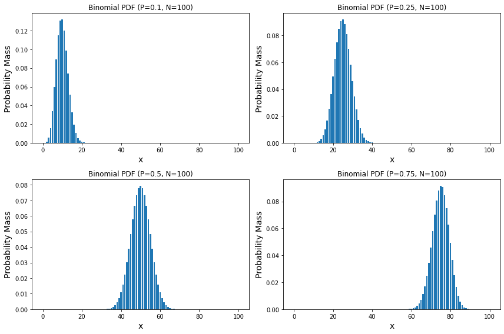

```python
from scipy.stats import binom
import matplotlib.pyplot as plt

# setting the values
n = 100 # number of instances
p_values = [0.1, 0.25, 0.5, 0.75] # defining list of probabilities
r = list(range(n + 1)) # defining list of r values


fig = plt.figure(figsize=(12,8))
for p, num in zip(p_values, range(1,5)):

    ax = fig.add_subplot(2,2, num)
    dist = [binom.pmf(r, n, p) for r in r ] # Test function
    ax.bar(r, dist)
    ax.set_ylabel('Probability Mass', fontsize=14)
    ax.set_xlabel('x', fontsize=14)
    ax.set_title(f"Binomial PDF (P={p}, N={n})")

plt.tight_layout()
plt.show()
```

# Visualizing the Binomial Cumulative Density Function

**Why we plot the Binomial Cumulative Density Function**

- The Cumulative distribution function (CDF) describes the cumulative probability that a given value or any value smaller than it will occur.
- The binomial cumulative distribution function lets one obtain the probability of observing less than or equal to *x* successes in *n* trials, with the probability *p* of success on a single trial.

**The mathematics of CDF**

- The formula for the binomial cumulative distribution function is: \[F(x;p,n) \Sigma_{i=0}^{x} \begin{pmatrix} n\\i \end{pmatrix}(p)^{i}(1-p)^{(n-i)} \]

**How to plot CDF using python scipy (v1.6.3) and matplotlib.**

- The [scipy binom class](https://docs.scipy.org/doc/scipy/reference/generated/scipy.stats.binom.html) provides a binomial discrete random variable.
- `scipy.stats.binom(*args, **kwds)`
- This class has several methods that can be used on a binomial discrete random variable.
- To plot the cumulative distribution function, we will use `binom.cdf(k,n,p)`
- **`k`:** the index of a given n values
- **`n`:** the total number of instances in the data
- **`p`:** the probability
- In example below, we will generate four subplots, each subplot will have a different value for *p*
- Note that as the probability for success increases, the binomial CDF will shift to the right, and vice versa.

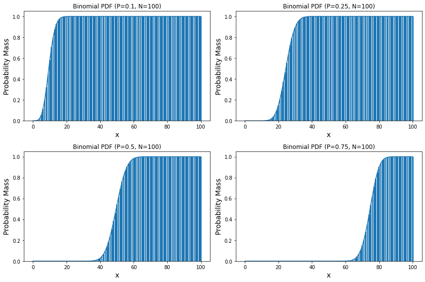

```python
import scipy.stats as stats
from scipy.stats import binom
import matplotlib.pyplot as plt
import numpy as np

fig = plt.figure(figsize=(12,8))
for p, num in zip(p_values, range(1,5)):

    ax = fig.add_subplot(2,2, num)
    cdf = stats.binom.cdf # Test function
    ax.plot(r, cdf(r, n, p))
    ax.bar(r, cdf(r, n, p))
    ax.set_ylabel('Probability Mass', fontsize=14)
    ax.set_xlabel('x', fontsize=14)
    ax.set_title(f"Binomial PDF (P={p}, N={n})")

plt.tight_layout()
plt.show()
```